# EasyVisa_Full_Code

## Data Pre-processing

### Outlier Check

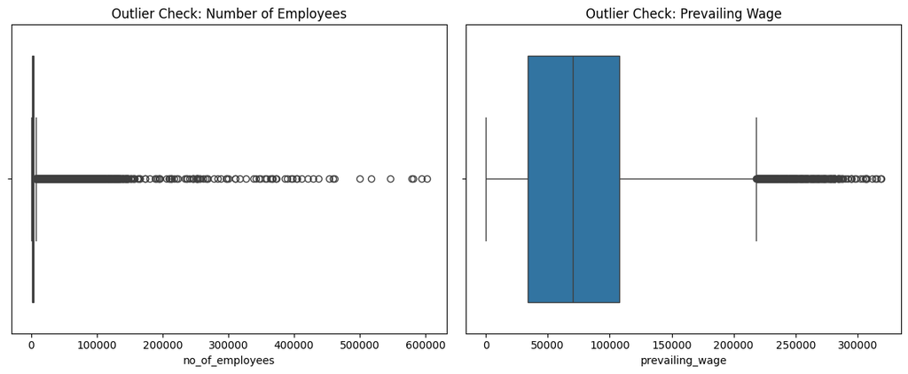

```
Outliers in 'no_of_employees': 1556
Outliers in 'prevailing_wage': 427
```

```python
# Check for outliers using boxplots
plt.figure(figsize=(12, 5))

plt.subplot(1, 2, 1)
sns.boxplot(x=data['no_of_employees'])
plt.title('Outlier Check: Number of Employees')

plt.subplot(1, 2, 2)
sns.boxplot(x=data['prevailing_wage'])
plt.title('Outlier Check: Prevailing Wage')

plt.tight_layout()
plt.show()

# Outlier counts using IQR method
Q1_emp = data['no_of_employees'].quantile(0.25)
Q3_emp = data['no_of_employees'].quantile(0.75)
IQR_emp = Q3_emp - Q1_emp
outliers_emp = ((data['no_of_employees'] < (Q1_emp - 1.5 * IQR_emp)) | (data['no_of_employees'] > (Q3_emp + 1.5 * IQR_emp))).sum()

Q1_wage = data['prevailing_wage'].quantile(0.25)
Q3_wage = data['prevailing_wage'].quantile(0.75)
IQR_wage = Q3_wage - Q1_wage
outliers_wage = ((data['prevailing_wage'] < (Q1_wage - 1.5 * IQR_wage)) | (data['prevailing_wage'] > (Q3_wage + 1.5 * IQR_wage))).sum()

print(f"Outliers in 'no_of_employees': {outliers_emp}")
print(f"Outliers in 'prevailing_wage': {outliers_wage}")
```

```python
data["case_status"] = data["case_status"].apply(lambda x: 1 if x == "Certified" else 0)
data.head()
```

|  | continent | education_of_employee | has_job_experience | requires_job_training | no_of_employees | yr_of_estab | region_of_employment | prevailing_wage | unit_of_wage | full_time_position | case_status |
| --- | --- | --- | --- | --- | --- | --- | --- | --- | --- | --- | --- |
| 0 | Asia | High School | N | N | 14513 | 2007 | West | 592.2029 | Hour | Y | 0 |
| 1 | Asia | Master's | Y | N | 2412 | 2002 | Northeast | 83425.6500 | Year | Y | 1 |
| 2 | Asia | Bachelor's | N | Y | 44444 | 2008 | West | 122996.8600 | Year | Y | 0 |
| 3 | Asia | Bachelor's | N | N | 98 | 1897 | West | 83434.0300 | Year | Y | 0 |
| 4 | Africa | Master's | Y | N | 1082 | 2005 | South | 149907.3900 | Year | Y | 1 |

```python
## Let's drop case status from the data
X = data.drop(["case_status"], axis=1)
y = data["case_status"]

## Let's create dummies
X = pd.get_dummies(X, drop_first=True)

## Let's split the data into train and test in the ratio 70:30
# Splitting data in train and test sets
X_train, X_test, y_train, y_test = train_test_split(X, y, test_size=0.3, random_state=1, stratify=y)
```

```python
print("Shape of Training set : ", X_train.shape)
print("Shape of test set : ", X_test.shape)
print("Percentage of classes in training set:")
print(y_train.value_counts(normalize=True))
print("Percentage of classes in test set:")
print(y_test.value_counts(normalize=True))
```

```
Shape of Training set :  (17836, 21)
Shape of test set :  (7644, 21)
Percentage of classes in training set:
case_status
1    0.667919
0    0.332081
Name: proportion, dtype: float64
Percentage of classes in test set:
case_status
1    0.667844
0    0.332156
Name: proportion, dtype: float64
```

```python
print("Training set shape:")
print("X_train shape:", X_train.shape)
print("y_train shape:", y_train.shape)

print("\nTesting set shape:")
print("X_test shape:", X_test.shape)
print("y_test shape:", y_test.shape)

# Calculate the percentage of the training and test sets relative to the total dataset
total_samples = len(X_train) + len(X_test)
train_percentage = (len(X_train) / total_samples) * 100
test_percentage = (len(X_test) / total_samples) * 100

print("\nPercentage of Training set:", train_percentage, "%")
print("Percentage of Test set:", test_percentage, "%")

# Proceed to build and evaluate your predictive model using X_train and y_train.
```

```
Training set shape:
X_train shape: (17836, 21)
y_train shape: (17836,)

Testing set shape:
X_test shape: (7644, 21)
y_test shape: (7644,)

Percentage of Training set: 70.0 %
Percentage of Test set: 30.0 %
```

### Data Preparation for modeling

[output not shown]

[output not shown]

## Model Building

### Model Evaluation Criterion

```python
# defining a function to compute different metrics to check performance of a classification model built using sklearn


def model_performance_classification_sklearn(model, predictors, target):
    """
    Function to compute different metrics to check classification model performance

    model: classifier
    predictors: independent variables
    target: dependent variable
    """

    # predicting using the independent variables
    pred = model.predict(predictors)

    acc = accuracy_score(target, pred)  # to compute Accuracy
    recall = recall_score(target, pred)  # to compute Recall
    precision = precision_score(target, pred)  # to compute Precision
    f1 = f1_score(target, pred)  # to compute F1-score

    # creating a dataframe of metrics
    df_perf = pd.DataFrame(
        {"Accuracy": acc, "Recall": recall, "Precision": precision, "F1": f1,},
        index=[0],
    )

    return df_perf
```

```python
def confusion_matrix_sklearn(model, predictors, target):
    """
    To plot the confusion_matrix with percentages

    model: classifier
    predictors: independent variables
    target: dependent variable
    """
    y_pred = model.predict(predictors)
    cm = confusion_matrix(target, y_pred)
    labels = np.asarray(
        [
            ["{0:0.0f}".format(item) + "\n{0:.2%}".format(item / cm.flatten().sum())]
            for item in cm.flatten()
        ]
    ).reshape(2, 2)

    plt.figure(figsize=(6, 4))
    sns.heatmap(cm, annot=labels, fmt="")
    plt.ylabel("True label")
    plt.xlabel("Predicted label")
```

**We are now done with pre-processing and evaluation criterion, so let's start building the model.**

### Model building with original data

**RANDOM FOREST**

```python
from sklearn.model_selection import train_test_split
from sklearn.ensemble import RandomForestClassifier
from sklearn.metrics import accuracy_score, classification_report

# Initialize and train the Random Forest classifier
rf_estimator = RandomForestClassifier(class_weight="balanced", random_state=1)
rf_estimator.fit(X_train, y_train)
```

```
RandomForestClassifier(class_weight='balanced', random_state=1)
```

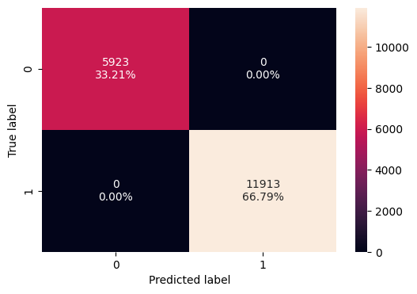

```python
## matrix for train data
confusion_matrix_sklearn(rf_estimator,X_train,y_train)
```

```python
# train performance
y_pred1 = rf_estimator.predict(X_train)

# Evaluate the model
print("Accuracy:", accuracy_score(y_train, y_pred1))
print("Classification Report:\n", classification_report(y_train, y_pred1))
```

```
Accuracy: 1.0
Classification Report:
               precision    recall  f1-score   support

           0       1.00      1.00      1.00      5923
           1       1.00      1.00      1.00     11913

    accuracy                           1.00     17836
   macro avg       1.00      1.00      1.00     17836
weighted avg       1.00      1.00      1.00     17836
```

```python
# performance on train data
rf_estimator_model_train_perf = model_performance_classification_sklearn(rf_estimator,X_train,y_train)
rf_estimator_model_train_perf
```

|  | Accuracy | Recall | Precision | F1 |
| --- | --- | --- | --- | --- |
| 0 | 1.0 | 1.0 | 1.0 | 1.0 |

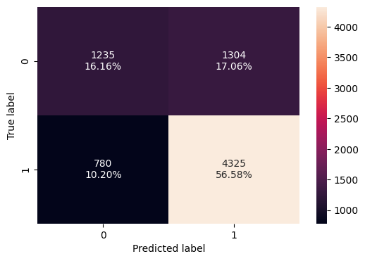

```python
# confusion matrix for test data
confusion_matrix_sklearn(rf_estimator,X_test,y_test)
```

```python
# performance of the test set
y_pred = rf_estimator.predict(X_test)

# Evaluate the model
print("Accuracy:", accuracy_score(y_test, y_pred))
print("Classification Report:\n", classification_report(y_test, y_pred))
```

```
Accuracy: 0.727367870225013
Classification Report:
               precision    recall  f1-score   support

           0       0.61      0.49      0.54      2539
           1       0.77      0.85      0.81      5105

    accuracy                           0.73      7644
   macro avg       0.69      0.67      0.67      7644
weighted avg       0.72      0.73      0.72      7644
```

```python
## Let's check performance for test data
rf_estimator_model_test_perf = model_performance_classification_sklearn(rf_estimator,X_test,y_test)
rf_estimator_model_test_perf
```

|  | Accuracy | Recall | Precision | F1 |
| --- | --- | --- | --- | --- |
| 0 | 0.727368 | 0.847209 | 0.768343 | 0.805851 |

## Hyperparameter Tuning - Random Forest

```python
# Choose the type of classifier.
rf_tuned = RandomForestClassifier(random_state=1, oob_score=True, bootstrap=True)

parameters = {
    "max_depth": list(np.arange(5, 15, 5)),
    "max_features": ["sqrt", "log2"],
    "min_samples_split": [3, 5, 7],
    "n_estimators": np.arange(10, 40, 10),
}

# Type of scoring used to compare parameter combinations
acc_scorer = metrics.make_scorer(metrics.f1_score)

# Run the grid search
grid_obj = GridSearchCV(rf_tuned, parameters, scoring=acc_scorer, cv=5, n_jobs=-1)
grid_obj = grid_obj.fit(X_train, y_train)

# Set the clf to the best combination of parameters
rf_tuned = grid_obj.best_estimator_

# Fit the best algorithm to the data.
rf_tuned.fit(X_train, y_train)
```

```
RandomForestClassifier(max_depth=np.int64(10), min_samples_split=7,
                       n_estimators=np.int64(20), oob_score=True,
                       random_state=1)
```

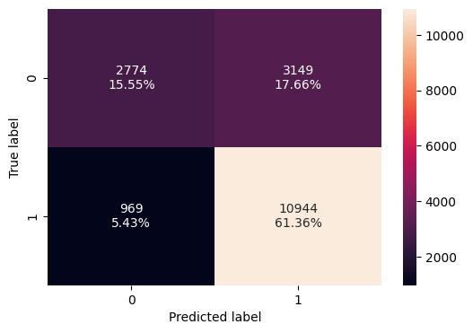

```python
confusion_matrix_sklearn(rf_tuned,X_train,y_train)
```

```python
# train performance
y_pred1 = rf_tuned.predict(X_train)

# Evaluate the model
print("Accuracy:", accuracy_score(y_train, y_pred1))
print("Classification Report:\n", classification_report(y_train, y_pred1))
```

```
Accuracy: 0.7691186364655752
Classification Report:
               precision    recall  f1-score   support

           0       0.74      0.47      0.57      5923
           1       0.78      0.92      0.84     11913

    accuracy                           0.77     17836
   macro avg       0.76      0.69      0.71     17836
weighted avg       0.76      0.77      0.75     17836
```

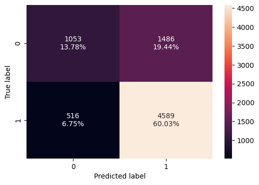

```python
# confusion matrix for test data
confusion_matrix_sklearn(rf_tuned,X_test,y_test)
```

```python
# performance of the test set
y_pred = rf_tuned.predict(X_test)

# Evaluate the model
print("Accuracy:", accuracy_score(y_test, y_pred))
print("Classification Report:\n", classification_report(y_test, y_pred))
```

```
Accuracy: 0.7380952380952381
Classification Report:
               precision    recall  f1-score   support

           0       0.67      0.41      0.51      2539
           1       0.76      0.90      0.82      5105

    accuracy                           0.74      7644
   macro avg       0.71      0.66      0.67      7644
weighted avg       0.73      0.74      0.72      7644
```

```python
rf_tuned_model_train_perf = model_performance_classification_sklearn(rf_tuned,X_train,y_train)
rf_tuned_model_train_perf
```

|  | Accuracy | Recall | Precision | F1 |
| --- | --- | --- | --- | --- |
| 0 | 0.769119 | 0.91866 | 0.776556 | 0.841652 |

```python
rf_tuned_model_test_perf = model_performance_classification_sklearn(rf_tuned,X_test,y_test)
rf_tuned_model_test_perf
```

|  | Accuracy | Recall | Precision | F1 |
| --- | --- | --- | --- | --- |
| 0 | 0.738095 | 0.898923 | 0.755391 | 0.82093 |

After hyperparameter tuning the model performance has generalized.

We have an F1 score of 0.84 and 0.82 on the training and test data, respectively.

The model has a high recall and a good precision.

**Decision Tree**

```python
dtree = DecisionTreeClassifier(random_state=1)
dtree.fit(X_train, y_train)
```

```
DecisionTreeClassifier(random_state=1)
```

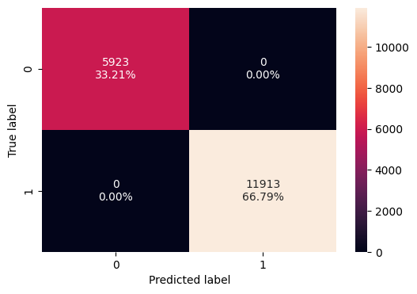

```python
confusion_matrix_sklearn(dtree, X_train, y_train)
```

```python
# train performance
y_pred1 = dtree.predict(X_train)

# Evaluate the model
print("Accuracy:", accuracy_score(y_train, y_pred1))
print("Classification Report:\n", classification_report(y_train, y_pred1))
```

```
Accuracy: 1.0
Classification Report:
               precision    recall  f1-score   support

           0       1.00      1.00      1.00      5923
           1       1.00      1.00      1.00     11913

    accuracy                           1.00     17836
   macro avg       1.00      1.00      1.00     17836
weighted avg       1.00      1.00      1.00     17836
```

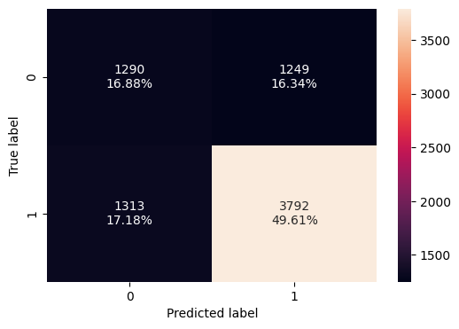

```python
## Let's create confusion matrix for test data
confusion_matrix_sklearn(dtree, X_test, y_test)
```

```python
# performance of the test set
y_pred = dtree.predict(X_test)

# Evaluate the model
print("Accuracy:", accuracy_score(y_test, y_pred))
print("Classification Report:\n", classification_report(y_test, y_pred))
```

```
Accuracy: 0.6648351648351648
Classification Report:
               precision    recall  f1-score   support

           0       0.50      0.51      0.50      2539
           1       0.75      0.74      0.75      5105

    accuracy                           0.66      7644
   macro avg       0.62      0.63      0.62      7644
weighted avg       0.67      0.66      0.67      7644
```

```python
## Let's check the performance on train data
decision_tree_perf_train = model_performance_classification_sklearn(dtree, X_train, y_train)
decision_tree_perf_train
```

|  | Accuracy | Recall | Precision | F1 |
| --- | --- | --- | --- | --- |
| 0 | 1.0 | 1.0 | 1.0 | 1.0 |

```python
## Let's check performance for test data
decision_tree_perf_test = model_performance_classification_sklearn(dtree, X_test, y_test)
decision_tree_perf_test
```

|  | Accuracy | Recall | Precision | F1 |
| --- | --- | --- | --- | --- |
| 0 | 0.664835 | 0.742801 | 0.752232 | 0.747487 |

the performance on the training set is significantly better than on the test set,

which indicates a potential overfitting issue.

**Hyperparameter Tuning - decision tree Classifier**

```python
# Choose the type of classifier.
dtree_estimator = DecisionTreeClassifier(class_weight="balanced", random_state=1)

# Grid of parameters to choose from
parameters = {
    "max_depth": np.arange(10, 30, 5),
    "min_samples_leaf": [3, 5, 7],
    "max_leaf_nodes": [2, 3, 5],
    "min_impurity_decrease": [0.0001, 0.001],
}

# Type of scoring used to compare parameter combinations
scorer = metrics.make_scorer(metrics.f1_score)

## Run grid search with n_jobs = -1
grid_obj = GridSearchCV(dtree_estimator, parameters, scoring=scorer, n_jobs=-1)

## Code to fit the grid_obj on the train data
grid_obj = grid_obj.fit(X_train, y_train)

# Set the clf to the best combination of parameters
dtree_estimator = grid_obj.best_estimator_

# Fit the best algorithm to the data.
dtree_estimator.fit(X_train, y_train)
```

```
DecisionTreeClassifier(class_weight='balanced', max_depth=np.int64(10),
                       max_leaf_nodes=2, min_impurity_decrease=0.0001,
                       min_samples_leaf=3, random_state=1)
```

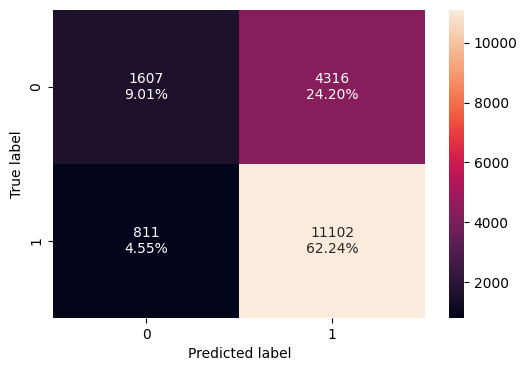

```python
confusion_matrix_sklearn(dtree_estimator, X_train,y_train)
```

```python
# train performance
y_pred1 = dtree_estimator.predict(X_train)

# Evaluate the model
print("Accuracy:", accuracy_score(y_train, y_pred1))
print("Classification Report:\n", classification_report(y_train, y_pred1))
```

```
Accuracy: 0.7125476564252075
Classification Report:
               precision    recall  f1-score   support

           0       0.66      0.27      0.39      5923
           1       0.72      0.93      0.81     11913

    accuracy                           0.71     17836
   macro avg       0.69      0.60      0.60     17836
weighted avg       0.70      0.71      0.67     17836
```

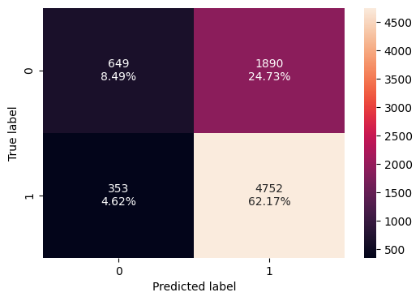

```python
confusion_matrix_sklearn(dtree_estimator, X_test,y_test)
```

```python
# performance of the test set
y_pred = dtree_estimator.predict(X_test)

# Evaluate the model
print("Accuracy:", accuracy_score(y_test, y_pred))
print("Classification Report:\n", classification_report(y_test, y_pred))
```

```
Accuracy: 0.706567242281528
Classification Report:
               precision    recall  f1-score   support

           0       0.65      0.26      0.37      2539
           1       0.72      0.93      0.81      5105

    accuracy                           0.71      7644
   macro avg       0.68      0.59      0.59      7644
weighted avg       0.69      0.71      0.66      7644
```

```python
## Let's check performance
dtree_tuned_model_train_perf = model_performance_classification_sklearn(dtree_estimator, X_train,y_train)
dtree_tuned_model_train_perf
```

|  | Accuracy | Recall | Precision | F1 |
| --- | --- | --- | --- | --- |
| 0 | 0.712548 | 0.931923 | 0.720067 | 0.812411 |

```python
## Let's check performance for test data on tuned estimator
dtree_tuned_model_test_perf = model_performance_classification_sklearn(dtree_estimator, X_test, y_test)
dtree_tuned_model_test_perf
```

|  | Accuracy | Recall | Precision | F1 |
| --- | --- | --- | --- | --- |
| 0 | 0.706567 | 0.930852 | 0.715447 | 0.809058 |

the decision tree classifier achieved a relatively higher accuracy and F1-score for class 1,

indicating that it is better at correctly classifying instances of class 1.

However, its performance on class 0 is lower, as evident from the lower recall and F1-score for class 0.

**AdaBoost Classifier**

```python
ab_classifier = AdaBoostClassifier(random_state=1)
ab_classifier.fit(X_train,y_train)
```

```
AdaBoostClassifier(random_state=1)
```

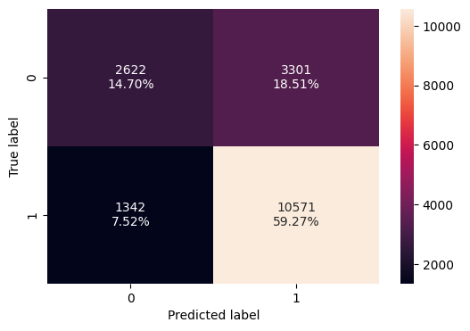

```python
confusion_matrix_sklearn(ab_classifier,X_train,y_train)
```

```python
# train performance
y_pred1 = ab_classifier.predict(X_train)

# Evaluate the model
print("Accuracy:", accuracy_score(y_train, y_pred1))
print("Classification Report:\n", classification_report(y_train, y_pred1))
```

```
Accuracy: 0.739683785602153
Classification Report:
               precision    recall  f1-score   support

           0       0.66      0.44      0.53      5923
           1       0.76      0.89      0.82     11913

    accuracy                           0.74     17836
   macro avg       0.71      0.67      0.68     17836
weighted avg       0.73      0.74      0.72     17836
```

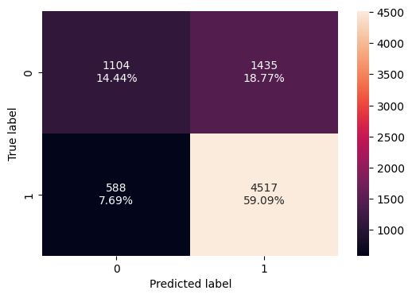

```python
confusion_matrix_sklearn(ab_classifier,X_test,y_test)
```

```python
# performance of the test set
y_pred = ab_classifier.predict(X_test)

# Evaluate the model
print("Accuracy:", accuracy_score(y_test, y_pred))
print("Classification Report:\n", classification_report(y_test, y_pred))
```

```
Accuracy: 0.7353479853479854
Classification Report:
               precision    recall  f1-score   support

           0       0.65      0.43      0.52      2539
           1       0.76      0.88      0.82      5105

    accuracy                           0.74      7644
   macro avg       0.71      0.66      0.67      7644
weighted avg       0.72      0.74      0.72      7644
```

```python
ab_classifier_model_train_perf = model_performance_classification_sklearn(ab_classifier,X_train,y_train)
ab_classifier_model_train_perf
```

|  | Accuracy | Recall | Precision | F1 |
| --- | --- | --- | --- | --- |
| 0 | 0.739684 | 0.88735 | 0.762039 | 0.819934 |

```python
ab_classifier_model_test_perf = model_performance_classification_sklearn(ab_classifier,X_test,y_test)
ab_classifier_model_test_perf
```

|  | Accuracy | Recall | Precision | F1 |
| --- | --- | --- | --- | --- |
| 0 | 0.735348 | 0.884819 | 0.758905 | 0.817039 |

**Hyperparameter Tuning - AdaBoost Classifier**

```python
# Choose the type of classifier.
abc_tuned = AdaBoostClassifier(random_state=1)

# Grid of parameters to choose from
parameters = {
    # Let's try different max_depth for base_estimator
    "estimator": [
        DecisionTreeClassifier(max_depth=1, class_weight="balanced", random_state=1),
        DecisionTreeClassifier(max_depth=2, class_weight="balanced", random_state=1),
        DecisionTreeClassifier(max_depth=3, class_weight="balanced", random_state=1),
    ],
    "n_estimators": np.arange(60, 100, 10),
    "learning_rate": np.arange(0.1, 0.4, 0.1),
}

# Type of scoring used to compare parameter  combinations
acc_scorer = metrics.make_scorer(metrics.f1_score)

# Run the grid search
grid_obj = GridSearchCV(abc_tuned, parameters, scoring=acc_scorer, cv=5)
grid_obj = grid_obj.fit(X_train, y_train)

# Set the clf to the best combination of parameters
abc_tuned = grid_obj.best_estimator_

# Fit the best algorithm to the data.
abc_tuned.fit(X_train, y_train)
```

```
AdaBoostClassifier(estimator=DecisionTreeClassifier(class_weight='balanced',
                                                    max_depth=1,
                                                    random_state=1),
                   learning_rate=np.float64(0.1), n_estimators=np.int64(60),
                   random_state=1)
```

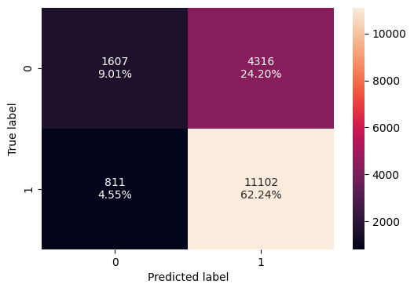

```python
confusion_matrix_sklearn(abc_tuned, X_train, y_train)
```

```python
# train performance
y_pred1 = abc_tuned.predict(X_train)

# Evaluate the model
print("Accuracy:", accuracy_score(y_train, y_pred1))
print("Classification Report:\n", classification_report(y_train, y_pred1))
```

```
Accuracy: 0.7125476564252075
Classification Report:
               precision    recall  f1-score   support

           0       0.66      0.27      0.39      5923
           1       0.72      0.93      0.81     11913

    accuracy                           0.71     17836
   macro avg       0.69      0.60      0.60     17836
weighted avg       0.70      0.71      0.67     17836
```

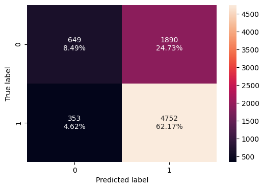

```python
# confusion matrix for test data
confusion_matrix_sklearn(abc_tuned, X_test, y_test)
```

```python
# performance of the test set
y_pred = abc_tuned.predict(X_test)

# Evaluate the model
print("Accuracy:", accuracy_score(y_test, y_pred))
print("Classification Report:\n", classification_report(y_test, y_pred))
```

```
Accuracy: 0.706567242281528
Classification Report:
               precision    recall  f1-score   support

           0       0.65      0.26      0.37      2539
           1       0.72      0.93      0.81      5105

    accuracy                           0.71      7644
   macro avg       0.68      0.59      0.59      7644
weighted avg       0.69      0.71      0.66      7644
```

```python
abc_tuned_model_train_perf = model_performance_classification_sklearn(abc_tuned,X_train,y_train)
abc_tuned_model_train_perf
```

|  | Accuracy | Recall | Precision | F1 |
| --- | --- | --- | --- | --- |
| 0 | 0.712548 | 0.931923 | 0.720067 | 0.812411 |

```python
abc_tuned_model_test_perf = model_performance_classification_sklearn(abc_tuned,X_test,y_test)
abc_tuned_model_test_perf
```

|  | Accuracy | Recall | Precision | F1 |
| --- | --- | --- | --- | --- |
| 0 | 0.706567 | 0.930852 | 0.715447 | 0.809058 |

The tuned AdaBoostClassifier is achieving similar performance on both the train and test sets

but it dosent seem to help much as its almost the same as before the hyperparameter tuning

**Gradient Boosting Classifier**

```python
gb_classifier = GradientBoostingClassifier(random_state=1)
gb_classifier.fit(X_train, y_train)
```

```
GradientBoostingClassifier(random_state=1)
```

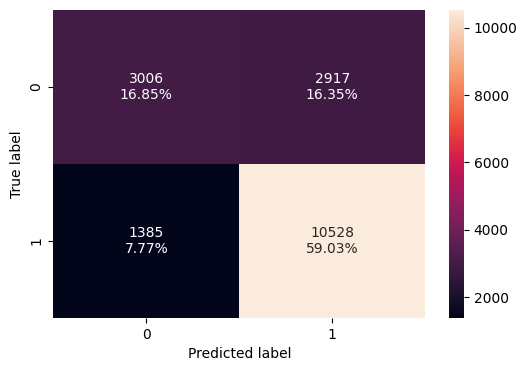

```python
confusion_matrix_sklearn(gb_classifier,X_train,y_train)
```

```python
# train performance
y_pred1 = gb_classifier.predict(X_train)

# Evaluate the model
print("Accuracy:", accuracy_score(y_train, y_pred1))
print("Classification Report:\n", classification_report(y_train, y_pred1))
```

```
Accuracy: 0.7588024220677282
Classification Report:
               precision    recall  f1-score   support

           0       0.68      0.51      0.58      5923
           1       0.78      0.88      0.83     11913

    accuracy                           0.76     17836
   macro avg       0.73      0.70      0.71     17836
weighted avg       0.75      0.76      0.75     17836
```

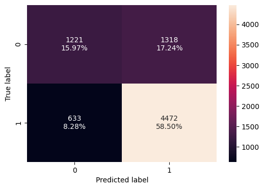

```python
confusion_matrix_sklearn(gb_classifier,X_test,y_test)
```

```python
# performance of the test set
y_pred = gb_classifier.predict(X_test)

# Evaluate the model
print("Accuracy:", accuracy_score(y_test, y_pred))
print("Classification Report:\n", classification_report(y_test, y_pred))
```

```
Accuracy: 0.7447671376242805
Classification Report:
               precision    recall  f1-score   support

           0       0.66      0.48      0.56      2539
           1       0.77      0.88      0.82      5105

    accuracy                           0.74      7644
   macro avg       0.72      0.68      0.69      7644
weighted avg       0.73      0.74      0.73      7644
```

```python
gb_classifier_model_train_perf = model_performance_classification_sklearn(gb_classifier,X_train,y_train)
gb_classifier_model_train_perf
```

|  | Accuracy | Recall | Precision | F1 |
| --- | --- | --- | --- | --- |
| 0 | 0.758802 | 0.88374 | 0.783042 | 0.830349 |

```python
gb_classifier_model_test_perf = model_performance_classification_sklearn(gb_classifier,X_test,y_test)
gb_classifier_model_test_perf
```

|  | Accuracy | Recall | Precision | F1 |
| --- | --- | --- | --- | --- |
| 0 | 0.744767 | 0.876004 | 0.772366 | 0.820927 |

**Hyperparameter Tuning - Gradient Boosting Classifier**

```python
# Choose the type of classifier.
gbc_tuned = GradientBoostingClassifier(
    init=AdaBoostClassifier(random_state=1), random_state=1
)

# Grid of parameters to choose from
parameters = {
    "n_estimators": [200, 250],
    "subsample": [0.9, 1],
    "max_features": [0.8, 0.9],
    "learning_rate": [0.1, 0.21, 0.1],
}

# Type of scoring used to compare parameter combinations
acc_scorer = metrics.make_scorer(metrics.f1_score)

# Run the grid search
## Complete the code to run grid search with cv = 5
grid_obj = GridSearchCV(gbc_tuned, parameters, scoring=acc_scorer,cv=5)

## Let's fit the grid_obj on train data
grid_obj = grid_obj.fit(X_train, y_train)

# Set the clf to the best combination of parameters
gbc_tuned = grid_obj.best_estimator_

# Fit the best algorithm to the data.
gbc_tuned.fit(X_train, y_train)
```

```
GradientBoostingClassifier(init=AdaBoostClassifier(random_state=1),
                           max_features=0.9, n_estimators=200, random_state=1,
                           subsample=0.9)
```

```python
confusion_matrix_sklearn(gbc_tuned,X_train,y_train)
```

[output not shown]

```python
# train performance
y_pred1 = gbc_tuned.predict(X_train)

# Evaluate the model
print("Accuracy:", accuracy_score(y_train, y_pred1))
print("Classification Report:\n", classification_report(y_train, y_pred1))
```

```
Accuracy: 0.7643529939448307
Classification Report:
               precision    recall  f1-score   support

           0       0.70      0.52      0.59      5923
           1       0.79      0.89      0.83     11913

    accuracy                           0.76     17836
   macro avg       0.74      0.70      0.71     17836
weighted avg       0.76      0.76      0.75     17836
```

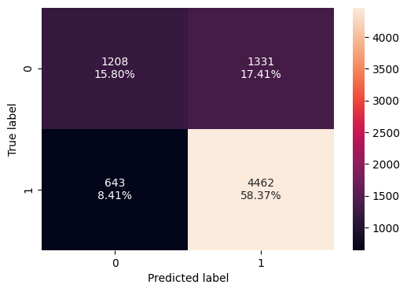

```python
confusion_matrix_sklearn(gbc_tuned,X_test,y_test)
```

```python
# performance of the test set
y_pred = gbc_tuned.predict(X_test)

# Evaluate the model
print("Accuracy:", accuracy_score(y_test, y_pred))
print("Classification Report:\n", classification_report(y_test, y_pred))
```

```
Accuracy: 0.7417582417582418
Classification Report:
               precision    recall  f1-score   support

           0       0.65      0.48      0.55      2539
           1       0.77      0.87      0.82      5105

    accuracy                           0.74      7644
   macro avg       0.71      0.67      0.68      7644
weighted avg       0.73      0.74      0.73      7644
```

```python
gbc_tuned_model_train_perf = model_performance_classification_sklearn(gbc_tuned,X_train,y_train)
gbc_tuned_model_train_perf
```

|  | Accuracy | Recall | Precision | F1 |
| --- | --- | --- | --- | --- |
| 0 | 0.764353 | 0.887434 | 0.786958 | 0.834182 |

```python
gbc_tuned_model_test_perf = model_performance_classification_sklearn(gbc_tuned,X_test,y_test)
gbc_tuned_model_test_perf
```

|  | Accuracy | Recall | Precision | F1 |
| --- | --- | --- | --- | --- |
| 0 | 0.741758 | 0.874045 | 0.77024 | 0.818866 |

## Model Performances

```python
# training performance comparison

# training performance comparison

models_train_comp_df = pd.concat(
    [
        decision_tree_perf_train.T,
        dtree_tuned_model_train_perf.T,
        rf_estimator_model_train_perf.T,
        rf_tuned_model_train_perf.T,
        ab_classifier_model_train_perf.T,
        abc_tuned_model_train_perf.T,
        gb_classifier_model_train_perf.T,
        gbc_tuned_model_train_perf.T,
    ],
    axis=1,
)
models_train_comp_df.columns = [
    "Decision Tree",
    "Tuned Decision Tree",
    "Random Forest",
    "Tuned Random Forest",
    "Adaboost Classifier",
    "Tuned Adaboost Classifier",
    "Gradient Boost Classifier",
    "Tuned Gradient Boost Classifier",
]
```

```python
# testing performance comparison

models_test_comp_df = pd.concat(
    [
        decision_tree_perf_test.T,
        dtree_tuned_model_test_perf.T,
        rf_estimator_model_test_perf.T,
        rf_tuned_model_test_perf.T,
        ab_classifier_model_test_perf.T,
        abc_tuned_model_test_perf.T,
        gb_classifier_model_test_perf.T,
        gbc_tuned_model_test_perf.T,
    ],
    axis=1,
)
models_test_comp_df.columns = [
    "Decision Tree",
    "Tuned Decision Tree",
    "Random Forest",
    "Tuned Random Forest",
    "Adaboost Classifier",
    "Tuned Adaboost Classifier",
    "Gradient Boost Classifier",
    "Tuned Gradient Boost Classifier",
]
```

```python
print("Training performance comparison:")
models_train_comp_df
```

```
Training performance comparison:
```

|  | Decision Tree | Tuned Decision Tree | Random Forest | Tuned Random Forest | Adaboost Classifier | Tuned Adaboost Classifier | Gradient Boost Classifier | Tuned Gradient Boost Classifier |
| --- | --- | --- | --- | --- | --- | --- | --- | --- |
| Accuracy | 1.0 | 0.712548 | 1.0 | 0.769119 | 0.739684 | 0.712548 | 0.758802 | 0.764353 |
| Recall | 1.0 | 0.931923 | 1.0 | 0.918660 | 0.887350 | 0.931923 | 0.883740 | 0.887434 |
| Precision | 1.0 | 0.720067 | 1.0 | 0.776556 | 0.762039 | 0.720067 | 0.783042 | 0.786958 |
| F1 | 1.0 | 0.812411 | 1.0 | 0.841652 | 0.819934 | 0.812411 | 0.830349 | 0.834182 |

The gradient boost classifier and tuned random forest classifier both perform well. However, given the critical nature of visa decisions—where both false positives and false negatives must be minimized the tuned random forest classifier is preferred, achieving the highest overall F1-score of approximately 0.82.

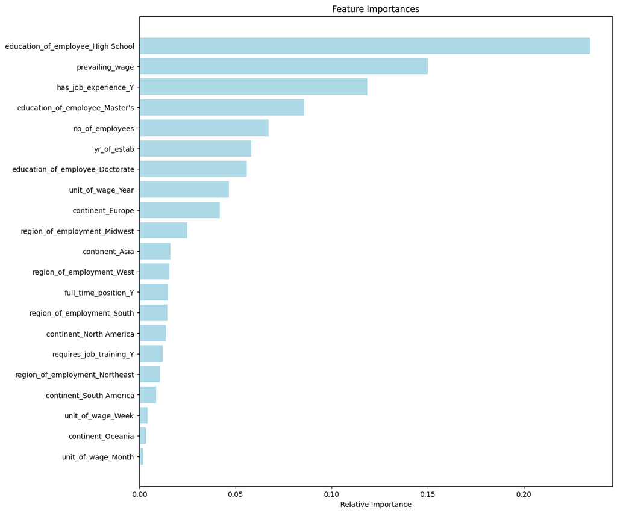

```python
feature_names = X_train.columns
importances = rf_tuned.feature_importances_
indices = np.argsort(importances)

plt.figure(figsize=(12, 12))
plt.title("Feature Importances")
plt.barh(range(len(indices)), importances[indices], color="lightblue", align="center")
plt.yticks(range(len(indices)), [feature_names[i] for i in indices])
plt.xlabel("Relative Importance")
plt.show()
```

## Actionable Insights and Recommendations

Applicants Most Likely to Have Their Visas Certified:

- Education: At least a Bachelor’s degree, with Master’s or Doctorate preferred. *
- Job Experience: Prior professional experience significantly boosts approval chances. *
- Prevailing Wage: Higher wage offers, especially those paid yearly, are associated with more certifications. (The median prevailing wage for approved cases is about $72,000.) *
- Continent: Applicants from Europe, Africa, and Asia have historically had higher certification rates. *

Applicants More Likely to Have Their Visas Denied:

- Education: Only a high school diploma. *

*Job Experience: Lack of prior work experience.*

- Prevailing Wage and Wage Unit: Lower wage offers, especially those paid hourly, are linked with more denials. (The median prevailing wage for denied cases is about $65,000.) *
- Continent: Applicants from South America, North America, and Oceania tend to face higher denial rates. *

Recommendations:

- For Employers: Prioritize candidates with higher education levels and relevant job experience. Offer competitive, annualized salaries to improve the likelihood of visa approval. *
- For Applicants: Enhance your qualifications and seek positions offering yearly wages to strengthen your application. *
- For Policymakers: Consider targeted support for applicants from regions or backgrounds with historically lower certification rates. *

Power Ahead